# DOT project summary

# Abstract

Administrative rulemaking is often presented as a straightforward translation of legislative delegations into agency rules, where bureaucrats adopt their most preferred policy given their constraints, often speeding up or slowing down the policy process to do so. The rulemaking process is indeed highly formulaic, requiring publication of a draft, external review, and public comment before a final rule is published. However, much of the politics of rulemaking may play out in the less formal and transparent process before a draft policy is published. In this stage, different priorities and constraints may drive decisions about which draft policies are published and when.

Theories of policymaking suggest that the politics of rulemaking may differ significantly in the pre-proposal stage. Yet, this part of the policy process has largely eluded quantitative study due to a lack of systematic data. This paper begins to fill this gap. We introduce a new dataset based on thousands of monthly internal project status reports by the U.S. Department of Transportation that allow us to track a rulemaking effort from its origin date through its finalization. Additionally, we develop several novel measures of prioritization and constraints that we measure both before and after a draft rule is made public, including the degree of agency resource constraints, internal agency prioritization, changes in sub-agency political appointees, congressional and presidential attention, and the threat of litigation and sanction by courts.

Our findings hold important implications for our understanding of transparency and bureaucratic policymaking within a representative democracy.

# To-do:

### Data

- add acting apointee data for testing
- Find a method to identify the year of each rule’s authorizing statute
- Infer missing withdrawal dates from the date last observed in stage withdrawal
- Add subagency administrators and secretary data
- OPM staff resources data for years other than 2016
- Select occupations and add [employee data](https://judgelord.github.io/FederalEmployees/summary.html#regulatory-budget) on rulewriting teams. If agencies do not use contractors too much, then the number of people per rule seems like a good metric. We may want to bring in budget when we talk about political attention, but in general, I’m not sure that we should assume that the budget has an effect independent of staffing.
- add summary plot of distribution of initiation reasons
- buckets for reasons for delay
- add acting head data from Susan’s email
- update data with new DOT reports
- merge in number of comments

### Model

- Properly code observations for previous and future stages
- Add covariates
- statistics at 50 percent
- describe `mstate` output
- describe cox coef interpretation
- rewrite with “stages”
- add model covars
- identify sensible values of covars at which to report results

### Done

- add OIRA report dates
- figure out `msfit` newdata argument
- drop IFRs (currently, IFR publication dates are dropped from models, but we are still using the NPRM dates from these observations and any Final Rule dates)

# Data

```r
load(here("data/DOT-monthly.Rdata"))
dotMonthly %<>% filter(!is.na(initiated)) # select rule-month observations with a dot report

load(here("data/DOT-perRule-perStage.Rdata"))
dotStage %<>% filter(!is.na(initiated)) # select rule-stage observations with a dot report

load(here("data/DOT-perRule.Rdata"))
dotRIN %<>% filter(!is.na(initiated)) # select rule observations with a dot report

dotMonthly %<>% group_by(RIN) %>%
  mutate(delay = paste(na.omit(color), collapse = ",")) %>%
  mutate(delayedever = grepl("Red|Yellow", delay))
```

[Google spreadsheet of variables](https://docs.google.com/spreadsheets/d/1CptLu6Xz7K14KF8PyELsiy-siYZHpi5jjmS9hMyO1xM/edit?usp=sharing)

### Summary Stats

We have initiation dates for 428 unique RINs. Of these, 134 were marked ‘delayed,’8 were marked ’potentially delayed,’ and 75 were marked ‘on time’ at the time they were last observed. However, DOT increasingly marks projects as ‘not on a schedule’ (134 RINs were last observed in the “Black” category). 199 projects were delayed at some point and 66 of these give a reason for delay.

317 RINs were initiated after 2008. 267 made it to the post-NPRM stage, 31 have been withdrawn, and 6 were terminated.

This table shows the average number of months after initiation at which certian milestones are reached:

| Document | *Average months until:* to Secretary | to ORIA | Published | *N* |
| --- | --- | --- | --- | --- |
| ANPRM | 6 | 14 | 17 | n = 62 |
| NPRM | 20 | 31 | 38 | n = 348 |
| SNPRM | 91 | 87 | 102 | n = 17 |
| Interim Final Rule | 5 | 17 | 19 | n = 25 |
| Final Rule | 50 | 55 | 62 | n = 267 |
| Withdrawal | 34 | 87 | 54 | n = 31 |
| Termination |  |  |  | n = 6 |

```r
lastreport <- max(dotRIN$DOTdate, na.rm = T)

dotRIN %<>% mutate(WithdrawalPublished = coalesce(WithdrawalPublished,Terminated)) %>%
  mutate(FinalRulePublished = ifelse(STAGE == "Final Rule" & is.na(FinalRulePublished), publicationactual, FinalRulePublished))

d <- dotRIN %>% filter(is.na(enddate), !is.na(initiated), DOTdate != lastreport) %>% ungroup()

# d %>% group_by(DOTdate) %>% count() %>% ungroup()

d %<>% select(RIN, initiated, DOTdate, STAGE, docket, fedreg, publicationactual, NPRMpublished, FinalRulePublished, WithdrawalPublished, IFRpublished)
# NOTE THERE IS SOME WORK TO DO HERE WITH PUBLICATION DATES

# in the meantime:
d  %<>% filter_at(vars(contains("published")), all_vars(is.na(.)))

write_csv(d, path= here("data/Unknown_EndDates.csv"))

IFRs <- dotRIN %>%
  filter(!is.na(IFRpublished), is.na(FinalRulePublished), DOTdate != lastreport) %>%
  select(RIN, initiated, DOTdate, STAGE, docket, fedreg, publicationactual, NPRMpublished, FinalRulePublished, WithdrawalPublished, IFRpublished)

write_csv(IFRs, path= here("data/IFRs_without_finals.csv"))

## note, need to correct missed NPRMs, IFRs, termination dates
noNPRMs <- dotRIN %>%
  filter(!is.na(FinalRulePublished) & is.na(NPRMpublished) & !is.na(initiated) ) %>%
  select(RIN, initiated, DOTdate, publicationactual, docket, title, fulltitle, fedreg, agency, PrevStage,DaysUntilFinalRule, FinalRulePublished, WithdrawalPublished, IFRpublished)

# FIXME
## need to correct missed NPRMs, IFRs, termination dates
## SFAR OST ORBB are FAA geographic flight restrictions
noNPRMs %<>%   filter(is.na(IFRpublished) & !str_detect(title, "SFAR|OSTT|ORBB") & !str_detect(PrevStage, "NPRM") & !str_detect(PrevStage, "Interim Final Rule"))

write_csv(noNPRMs, path= here("data/finals_without_NPRMs.csv"))

# other no NPRMS
# "FHWA-2017-003" is not in the federal register
```

### Missing data

We have final outcomes for 256 RINs, 97 RINs were in progress as of 2018-09-01, and 29 rules dropped out with unknown outcomes [[download .csv](https://raw.githubusercontent.com/judgelord/DOT/master/data/Unknown_EndDates.csv)], including these:

```r
kable(d %>% select(RIN, DOTdate, docket, fedreg)%>% top_n(5))
```

| RIN | DOTdate | docket | fedreg |
| --- | --- | --- | --- |
| 2125-AF78 | 2018-03-01 |  | Undetermined: None |
| 2105-AE31 | 2018-03-01 |  | Withdrawal: None |
| 2125-AF65 | 2017-09-01 |  | Undetermined: None |
| 2105-AE29 | 2017-09-01 | DOT-OST-2013-0014 | Undetermined: None |
| 2130-AC17 | 2017-08-01 | FRA-2009-0106 | Undetermined: None |
| 2127-AK87 | 2014-05-01 |  | Undetermined: None |
| 2126-AB32 | 2011-12-01 |  | Undetermined: None |
| 2137-AE75 | 2011-12-01 |  | Undetermined: None |
| 2137-AE67 | 2011-04-01 | PHMSA 2010-0254/FMCSA 2010-0312 | Undetermined: None |

We have 2 IFRs without Final Rules [[download .csv](https://raw.githubusercontent.com/judgelord/DOT/master/data/IFRs_without_finals.csv)]

```r
kable(IFRs %>% select(RIN, DOTdate, docket, fedreg, IFRpublished, FinalRulePublished) )
```

| RIN | DOTdate | docket | fedreg | IFRpublished | FinalRulePublished |
| --- | --- | --- | --- | --- | --- |
| 2127-AL30 | 2016-05-01 |  | Undetermined: None | 2013-01-23 | NA |
| 2120-AJ92 | 2012-03-01 | FAA-2011-0186 | Disposition of Comments: 77 FR 11385 | 2011-03-08 | NA |

### Odd cases

RINs without NPRMs:

- RINs 2132-AB33 and 2125-AF75, [FHWA-2017-003](https://www.federalregister.gov/documents/2017/11/29/2017-25762/metropolitan-planning-organization-coordination-and-planning-area-reform) “simply carries out the statutory language found in Public Law 115-33 without interpretation to rescind the December 2016 Final Rule”
- 2137-AF17 [PHMSA-2016-0011](https://www.federalregister.gov/documents/2016/08/15/2016-19406/hazardous-materials-fast-act-requirements-for-flammable-liquids-and-rail-tank-cars) “simply codify these non-discretionary statutory mandates, PHMSA finds that timely execution of agency functions would be impeded by the procedures of public notice that are normally required by the Administrative Procedure Act.”
- 2120-AK25, [FAA-2013-0503](https://www.govinfo.gov/content/pkg/FR-2013-07-02/html/2013-15843.htm) “codifies the statutory prohibition and relieving circumstances into the regulations in 14 CFR. The FAA has no discretion to change any provision of the statute, and it is being codified into the regulations as adopted.”
- 2126-AB58, [FMCSA–2012–0378](https://www.fmcsa.dot.gov/sites/fmcsa.dot.gov/files/docs/Federal_Register_Final_Rule_Tranportation_of_Agricultural_Commodities_508CLN.pdf)“simply adopts jurisdictional limitations enacted by Congress, and FMCSA therefore finds”good cause“” under 5 U.S.C. 553 to promulgate this rule as a final rule because prior notice and comment would be “unnecessary”" under the circumstances"
- 2126-AB27, [FMCSA-2010-0186](https://www.federalregister.gov/documents/2010/09/21/2010-23479/parts-and-accessories-necessary-for-safe-operation-antilock-brake-systems), with a “direct final rule” published on 09/21/2010
- 2127-AK61 and [2127-AK54](https://www.nhtsa.gov/sites/nhtsa.dot.gov/files/fmvss/CARS_Amendment_1.pdf) appear to be notices and ammendments to the 2127-AK53, [NHTSA-2009-0120](https://www.federalregister.gov/documents/2009/07/29/E9-17994/requirements-and-procedures-for-consumer-assistance-to-recycle-and-save-program) final rule published on 07/29/2009. “This rulemaking is economically significant” but “The rule is being issued without first providing a notice and an opportunity for public comment. As noted above, the Act provides that the rule shall be issued within 30 days after enactment, “notwithstanding” the requirements of 5 U.S.C. 553, the Federal law requiring notice and comment. Further, given that schedule and the necessity of quickly beginning to implement this 4-month program with a statutorily fixed end date, the agency finds for good cause that providing notice and comment is impracticable and contrary to the public interest.”–“Although there was not time to provide notice and an opportunity to comment prior to issuance of this final rule, NHTSA did engage in extensive outreach prior to its issuance with representatives of those entities most knowledgeable about the subject matter.”
- 2120-AJ01, [FAA-2006-26139](https://www.federalregister.gov/documents/2009/07/15/E9-16777/part-121-pilot-age-limit): “The FAA finds that notice and public comment to this final rule are unnecessary and contrary to the public interest. This final rule is a result of the Act. Because this rule implements Congressional mandates, good cause exists for the FAA to amend without notice its rules concerning pilot age limits. A legislative mandate of this nature makes it unnecessary to provide an opportunity for notice and comment.”
- 2120-AJ37, [FAA-2008-0937](https://www.federalregister.gov/documents/2009/05/14/E9-11289/drug-and-alcohol-testing-program): “We find good cause exists under 5 U.S.C. 553(b)(B) and (d)(3) to implement this final rule immediately without prior notice and comment. This rule merely reorganizes existing regulations governing drug and alcohol testing into their own part and makes clarifying changes to the existing parts of the rules necessitated by the reorganization.”
- 2126-AA98 [FMCSA-2009-0127](https://www.federalregister.gov/documents/2010/02/01/2010-1955/safety-requirements-for-operators-of-small-passenger-carrying-commercial-motor-vehicles-used-in)“In this case, notice and comment are unnecessary. The final rule amends FMCSA’s regulations to make them consistent with section 4136 of SAFETEA-LU, a provision which makes the FMCSRs applicable to the operation of 9- to 15-passenger vehicles when such vehicles are operated for direct compensation, in interstate commerce, regardless of the distance traveled. Because the statutory language does not provide FMCSA any discretion in adopting the necessary changes to its regulations, FMCSA finds good cause under 5 U.S.C. 553(b) that prior notice and comment on this final rule is unnecessary.”

RINs where the NPRM is unclear:

- 2130-AC37, [FRA-2008-0059](https://www.federalregister.gov/documents/2014/01/10/2013-31417/railroad-workplace-safety-adjacent-track-on-track-safety-for-roadway-workers) “further responds to the petitions, addresses the comments on the petitions, and amends and clarifies certain sections of the November 30, 2011, final rule.”

### Combining data sources

Adding DOT Internal Status Reports to OIRA and Unified Agenda Reports gives a richer picture of rulemaking. Data by RIN, date, and source:

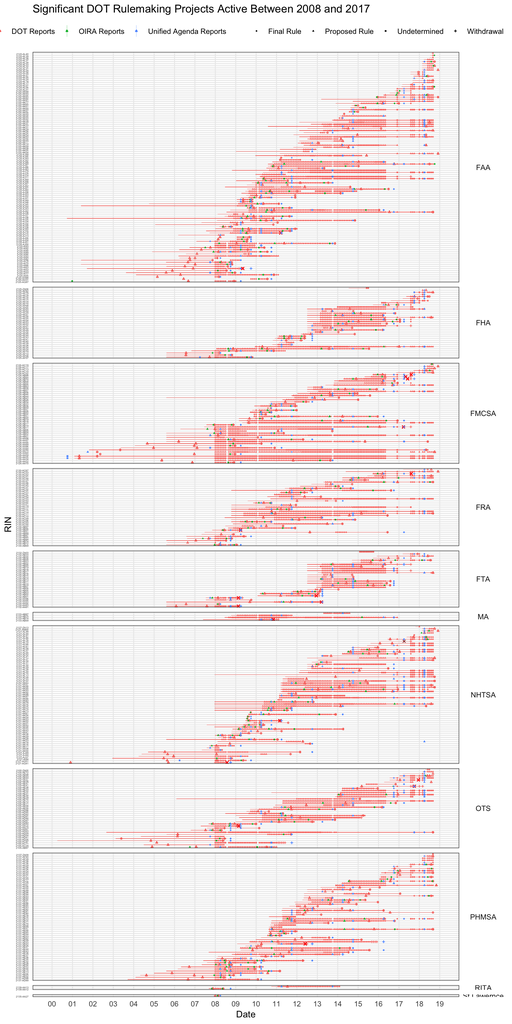

```r
# If project is ongoing, define enddate as date last observed (for plotting active project status)
dotMonthly %<>% mutate(end = if_else( is.na(enddate), reportdate, enddate) )

# Consolidate like stages for plotting:
dotMonthly$STAGE %<>% {gsub("Terminat.*", "Withdrawal",.)}
dotMonthly$STAGE %<>% {gsub(".2$", "", .)}
dotMonthly$STAGE %<>% {gsub(".3$", "", .)}
dotMonthly$STAGE %<>% {gsub(".4$", "", .)}
dotMonthly$STAGE %<>% {gsub("Notice", "Proposed Rule", .)}
dotMonthly$STAGE %<>% {gsub("Other", "Undetermined", .)}
dotMonthly$STAGE %<>% {gsub("Prerule", "Proposed Rule", .)}
dotMonthly$STAGE %<>% {gsub("Interim Final Rule", "Final Rule", .)}
dotMonthly$STAGE %<>% {gsub("SNPRM", "Proposed Rule", .)}

dotMonthly %>% # filter(reportdate > as.Date("2008-01-01")) %>%
ggplot(aes(x = RIN)) +
  geom_linerange(aes(ymin=initiated, ymax=end, color="DOT Reports"), size=.1) +
  geom_point(aes(y = DOTdate, color = "DOT Reports", shape = STAGE), size = .5) +
  geom_point(aes(y = ANPRMpublished, color = "DOT Reports"), shape = 2, size = .5) +
  geom_point(aes(y = NPRMpublished, color = "DOT Reports"), shape = 2, size = .5) +
  geom_point(aes(y = SNPRMpublished, color = "DOT Reports"), shape = 2, size = .5) +
  geom_point(aes(y = FinalRulePublished, color = "DOT Reports"), shape = 1, size = .5) +
  geom_point(aes(y=IFRpublished, color = "DOT Reports"), shape = 1, size = .5) +
  geom_point(aes(y=WithdrawalPublished), color="red", shape = 4, size = 1) +
  geom_point(aes(y=Terminated), color="red4", shape = 4, size = 1) +
  geom_point(aes(y = DATE_RECEIVED, color = "OIRA Reports", shape = STAGE), size = .5) +
  geom_point(aes(y = UnifiedAgendaDate, color = "Unified Agenda Reports", shape = STAGE), size = .5) +
  facet_grid(acronym~., scales = "free_y", space = "free_y")+
  coord_flip() +
  scale_y_date(lim = c(as.Date("2000-01-01"), as.Date("2019-01-01")),
             breaks=date_breaks(width = "1 year"),
             labels = date_format("%y"),
             minor_breaks=NULL) +
  ggtitle('Significant DOT Rulemaking Projects Active Between 2008 and 2017') +
  labs( x = "RIN", y = "Date", color = "", shape = "")+
  theme(axis.text.y = element_text(size = 3,
                       angle = 0,
                       hjust = 1,
                       vjust = 1),
        axis.ticks = element_blank(),
        strip.text.y = element_text(angle = 0),
        strip.background = element_blank(),
        legend.position = "top")
```

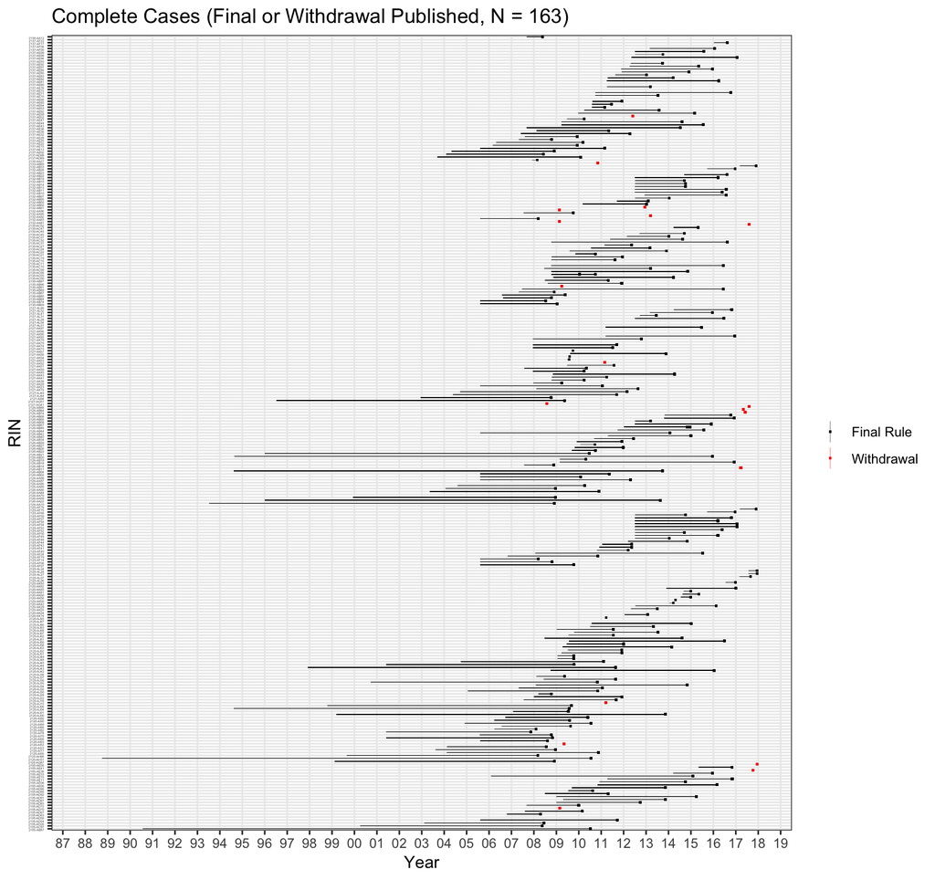

```r
######### TIMELINES #####################
dotcomplete <- filter(dotMonthly, !is.na(FinalRulePublished) | !is.na(WithdrawalPublished))

dotcomplete2008 <- subset(dotcomplete, initiated>"2008-01-01")


# TOY Timeline
ggplot(dotcomplete, aes(x=RIN)) +
  # facet_grid(agency ~ .) +
  geom_linerange(aes(ymin=initiated, ymax=enddate, color="black"), size=.1) +
  #geom_point(aes(y=WithdrawalPublished, color="red", shape = 4), size=.4) +
  geom_point(aes(y=WithdrawalPublished, color="red"), shape = 15, size=.4) +
  geom_point(aes(y=FinalRulePublished, color="black"), shape = 15, size=.4) +
  coord_flip() +
  scale_y_date(lim = c(as.Date("1988-01-01"), as.Date("2018-01-01")),
               breaks=date_breaks(width = "1 year"), labels = date_format("%y"),
               minor_breaks=NULL)+
  ggtitle('Complete Cases (Final or Withdrawal Published, N = 163)')+ xlab("RIN")+ylab("Year")+
  scale_color_identity("",guide="legend", labels = c("Final Rule", "Withdrawal"))+
  theme(axis.text.y =
          element_text(size  =2,
                       angle = 0,
                       hjust = 1,
                       vjust = 1))
```

Notice how the DOT (esp. FTA and FHA) initiated a large number of projects shortly after Obama’s reelection, probably waiting for assurance that they would be able to complete their work.

## Rulemaking stages

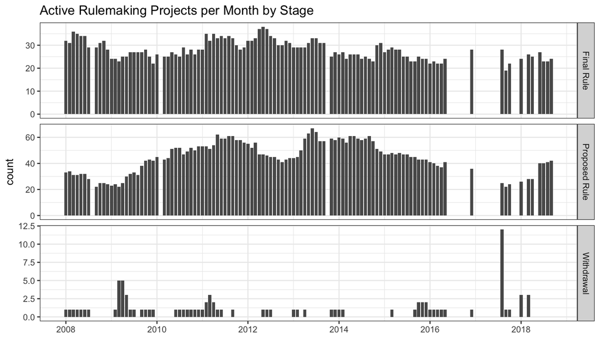

```r
# stage histogram
ggplot(dotMonthly %>% filter(STAGE %in% c("Withdrawal","Proposed Rule", "Other", "Final Rule", "Interim Final Rule"))) +
  stat_count(aes(DOTdate)) +
  facet_grid(STAGE~., scales = "free_y") +
  labs(title = "Active Rulemaking Projects per Month by Stage", x = "")
```

```r
  #scale_y_date(breaks=date_breaks(width = "1 year"), labels = date_format("%y"), minor_breaks=NULL)
```

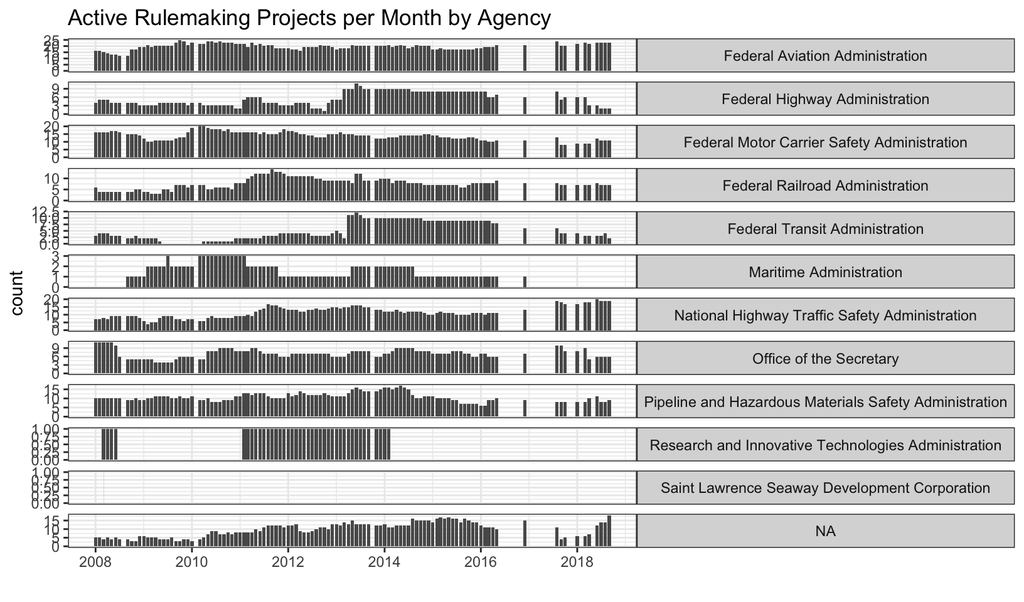

```r
# stage histogram
ggplot(dotMonthly %>% ungroup()) +
  stat_count(aes(DOTdate)) +
  facet_grid(AGENCY~., scales = "free_y") +
  labs(title = "Active Rulemaking Projects per Month by Agency", x = "") +
  theme(strip.text.y = element_text(angle = 0))
```

Rulemaking Projects Completed 2008-2018

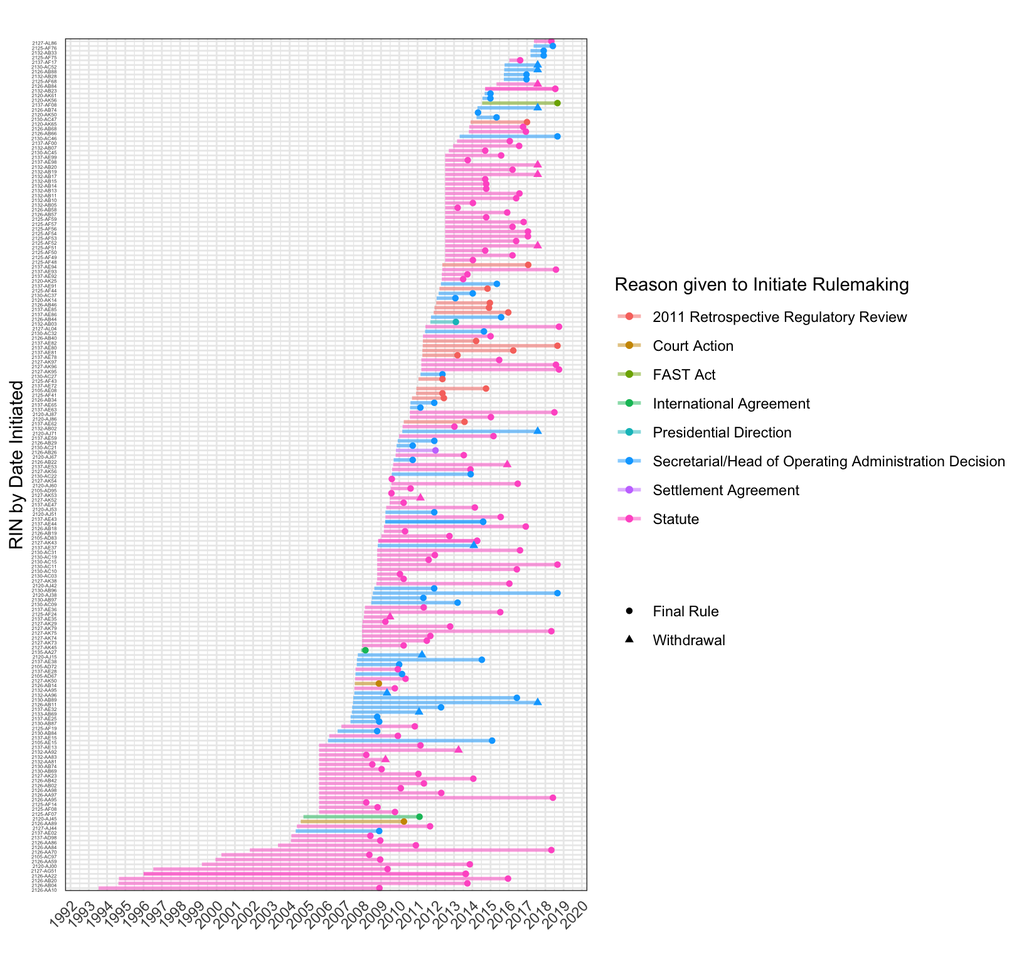

```r
# Consolidate like stages for plotting:
dotRIN$STAGE %<>% {gsub("Terminat.*", "Withdrawal",.)}
dotRIN$STAGE %<>% {gsub(".2$", "", .)}
dotRIN$STAGE %<>% {gsub(".3$", "", .)}
dotRIN$STAGE %<>% {gsub(".4$", "", .)}
dotRIN$STAGE %<>% {gsub("Notice", "Proposed Rule", .)}
dotRIN$STAGE %<>% {gsub("Other", "Undetermined", .)}
dotRIN$STAGE %<>% {gsub("Prerule", "Proposed Rule", .)}
dotRIN$STAGE %<>% {gsub("Interim Final Rule", "Final Rule", .)}
dotRIN$STAGE %<>% {gsub("SNPRM", "Proposed Rule", .)}

  dotRIN %>% filter(STAGE %in% c("Final Rule", "Withdrawal")) %>%
    mutate(end = if_else( is.na(enddate) & DOTdate != "2018-09-01", reportdate, enddate) ) %>% #filter(prompt %in% c("Secretarial/Head of Operating Administration Decision","2011 Retrospective Regulatory Review" , "International Agreement", Settlement Agreement") ) %>%
  drop_na(initiated, end, prompt) %>%
    filter(prompt != "None") %>%
  ggplot() +
  geom_segment(aes(y = reorder(RIN,initiated), yend = reorder(RIN,initiated), x = initiated, xend = end, color = prompt), alpha = .5, size = 1) +
  #geom_point(aes(y = RIN, x = initiated, color = prompt), shape = ">") +
  geom_point(aes(y = reorder(RIN,initiated), x = end, color = prompt, shape = STAGE)) +
  scale_x_date(limits = c(as.Date("1993-01-01"),as.Date("2019-01-01")),
               breaks=date_breaks(width = "1 year"),
             labels = date_format("%Y") )+

    #geom_smooth(aes(x= if_else(initiated > as.Date("2008-01-01"), initiated, NA), y= enddate), method = "lm" ) +
  labs(title = "", x = "", y = "RIN by Date Initiated", color = "Reason given to Initiate Rulemaking", shape = "") +
  theme(axis.text.y = element_text(size = 3, vjust = 1),
        axis.text.x = element_text(angle = 45,
                                   hjust = 1),
        axis.ticks = element_blank() )
```

## Time from rulemaking project initiation to completion

```r
# Initiated * Published Fit (takes 4 years from initiated)
ggplot(dotRIN#%>% filter(enddate > as.Date("2008-01-01"))
       ) +
  geom_point(aes(x=FinalRulePublished, y= initiated, color=color)) +
  geom_point(aes(WithdrawalPublished, initiated), color = "red", shape = 4) +
  geom_smooth(aes(x=FinalRulePublished, y = initiated), method='auto')+
  #FIXME
  # scale_y_date(breaks=date_breaks(width = "1 year"), labels = date_format("%Y"),
  #              minor_breaks=NULL)+
  # scale_x_date(breaks=date_breaks(width = "1 year"), labels = date_format("\'%y"),
  #              minor_breaks=NULL) +
  scale_color_identity("",guide="legend", labels = c("No Timeline",
                                                     "On Time",
                                                     "Delayed",
                                                     "Likely Delayed"))+
  ggtitle('Significant DOT Final Rules and Withdrawals Published 2008 - 2017
          (The average Final Rule takes 4 years, but is scheduled for less)') +
  xlab("Publication")+ylab("Initiated")
```

[output not shown]

# Models

Given these questions and the time-series nature of our data (monthly status reports with changing covariate values), we use duration models. Because we are interested in how policies may move through multiple stages of the policymaking process, we use a multi-state model. Doing so allows us to simultaneously model how different factors may affect a policy at different stages (i.e. states), while also modeling a common frailty. We could model each stage separately, but this would ignore correlation within rules across stages.

Two interpretable statistics address each of our main questions.

First, we estimate “transition probabilities” (i.e. the probability that a policy will advance to each possible future state at a given time) using the Aalen-Johansen estimator and the cumulative incidence function (the function estimating the number of observations that have transitioned to and from each state over time).

Second, we estimate the probability that a given transition will occur in a given time window using the Kaplan-Meier estimator. Covariates may increase or decrease the likelihood that a given transition will occur, thus increasing or decreasing the estimated rate of advancing from a given stage to a given stage in the policymaking process, and thus the Kaplan-Meier estimate that a given transition will occur after a given date.

## Covariates

[Google spreadsheet of variables](https://docs.google.com/spreadsheets/d/1CptLu6Xz7K14KF8PyELsiy-siYZHpi5jjmS9hMyO1xM/edit?usp=sharing)

Some are measured at the rule level, others at the agency level, and others for all rules at a given point in time. Many vary by month or year. We will include a frailty by rule and may need cluster standard errors by rule or agency depending on the covariates.

Many covariates may be correlated and we really should be modeling them as indicators of the latent factors that affect policymaking. For example, observed covariates may be grouped into broader, more discrete concepts like the resources the agency has, the technical complexity of the rule, and the political contentiousness of the rule.

##### Resources

Resources measures:

- sub-agency budget? - can we get the budget for rulemaking activities? Is this different than estimating SES?
- “lack of resources” or “lack of staffing” claimed [0,1], a subset of delayed rules
- number of SES / # of rules per year (ideally at sub-agency level if we have SES data for that)
- secretary prompt [0,1] - how many missing?
- Non-acting subagency head [0,1]
- Same president as initiation date [0,1]
- Same secretary as initiation date [0,1]
- Same subagency head as initiation date [0,1]

##### Complexity

Complexity measurements:

- “coordination necessary” claimed [0,1], subset of delayed rules
- “unanticipated issues/impacts requiring further analysis”*“awaiting development of additional data” claimed [0,1], a subset of delayed rules
- the score of the abstract on Benoit’s political sophistication/complexity
- second comment period [1,0] (though this may also be a measure of external, interest group constraint)
- the number of comments? (to me this is more about salience and contentiousness than complexity)
- MORE MEASURES?

##### Contentiousness:

White House and Secretary alignment measures:

- “other, higher priorities” claimed [0,1] (is it right to interpret this way? Priority could also be internal…which would make it, what? Not a resource per se)
- initiated under same president [0,1] (same party president? we have a few started under Clinton, finished under Obama)
- went to Secretary twice [0,1]
- days between going to secretary going to ORIA (average if multiple times)
- went to ORIA twice [0,1]
- Did ORIA make changes [0,1]
- days between going to ORIA and publication (count days from the first or last time at ORIA? )

Congress alignment measures:

- positive-negative sentiment words in subcommittee budget report
- positive-negative sentiment words in the subcommittee hearing
- legislative deadline exists [0,1]
- legislative deadline past [0,1]
- prompting action is legislation [0,1] (speeds up rulemaking?)
- legislation is pending [0,1] (slows rulemaking)
- Reg flex required [0,1] slowing?
- unified congress

Litigation threat:

- court deadline exists [0,1]
- court deadline past [0,1]
- number of lawsuits against the subagency in the past x years
- avg number of lawsuits against the agency per year of administration (this is perhaps better suited for a model that is not just DOT)
- litigation threatened in comments? [0,1]

## Congressional attention/opposition:

Below are examples of positive and negative sentiment about the FAA from the 2018 appropriations subcommittee report. Much it is very neutral, but it is fair to say that this actually reflects neutral attitudes. Sentiment analysis allows us to tally up the positive and negative words for each subagency. Other scholars have measured the length of the section on each subagency, but this mostly just reflects the size and diversity of its budget.

#### Examples:

POSITIVE:

The Committee is encouraged by the additional measures the FAA is taking to enhance outreach to communities affected by new flightpaths. The Committee recommendation includes an additional $2,000,000 to support the FAA’s ongoing efforts to address community noise concerns. The Committee supports research that is being conducted through the FAA’s Center of Excellence for Alternative Jet Fuel and Environment, the Aviation Sustainability Center (ASCENT) on the impact of aviation noise on both sleep and cardiovascular health. The Committee commends the FAA Office of Commercial Space Transportation’s efforts to promote private sector lunar exploration and development and encourages the FAA to explicitly define non-interference and to enhance its payload review process to provide companies planning private sector lunar development with the security and predictability necessary to support substantial investments.

NEGATIVE:

The Committee is concerned by the FAA’s decision to extend by five years its aging Mission Support Network, a decision which carries both technology and cost implications.

# Notes

#### DOT Report - Unified Agenda crosswalk

List of unique rule stages and how we code each (Note /2 means the second such document for the same RIN):

[1] “Final Rule” = Final Rule  
[2] “Undetermined” = Undetermined  
[3] “NPRM” = Proposed Rule  
[4] “SNPRM” = SNPRM (sometimes folded into Proposed Rule) [5] “Interim Final Rule/4” = Interim Final Rule  
[6] “Interim Final Rule” = Interim Final Rule  
[7] “Withdrawal” = Withdrawal  
[8] “Other” = Undetermined  
[9] “ANPRM” = Prerule  
[10] “Final Rule/2” = Final Rule/2  
[11] “NPRM/2”= Proposed Rule  
[12] “SNPRM/2”= SNPRM  
[13] “Notice” = Notice  
[14] “Supplemental Notice of Intent” = Prerule  
[15] “Reconsideration of Final Rule” = Final Rule  
[16] “Disposition of Comments” = Other  
[17] “Request for Comments” = Other  
[18] “Final Rule with Request for Comments” = Final Rule [19] “Termination” = Termination (sometimes folded into Withdrawal)